# Image Classification (Street View House Number )

## HTML Version

Please check out the following link to view HTML version of this page: http://htmlpreview.github.io/?https://github.com/kyloop/sb_capstone2/blob/master/capstone2-milestone2.html

## Background

One of trendy topics in machine learning industry would be image classification. The concept of this project is to make prediction on “Street View House Number (SVHN)” from about 100k labelled real-world images which was collected was used by Google to match the real house number and its geolocation. This project includes data exploration which shows the distribution of colors among images with distinctive class labels. Visualization is another major part of this exerise which reveals how the images are displayed with different channel of colors (i.e. RGB and GrayScale). Modeling is the ultimate goal of this project, we will train models to make classification on the images with digits, so that the final trained model are potentially able to read and classify ten classes of digitals (i.e. 0-9).

## Client and Audience

Classification is a current trendy and practical topic in machine learning industry. With rapid growing of mobile application and advanced camera technology, object recognition technique also becomes popular and demanding. Prior researches are already accomplished, Similar dataset MNIST is a perfect example that image with digits objects are able classified by machine learning algorithms (e.g. SVM). For this particular exercise, we will attempt to utilize Deep Learning techniques to tackle the "House Number" classification problem. The result of this study could be a reference for anyone who studes image classification or object recognition subjects.

## Questions to be addressed

**- Discover the distribution of colors among images with according class labels**

**- Visualize images with different channels of colors**

**- Discover models perform differently with channels of colors**

**- Determine the best model(s) for classifying images with digits**

### Contents

- I. Import data and Data Cleaning
- II. Exploratory Data Analysis (EDA) and Visualization
  - Distribution of Class Labels
- III. Images Visualization
  - Visualize original images (Pixels: 32 x 32 x 3)
  - Visualize modified images (Pixels: 128 x 128 x 3)
  - Visualize images with 3 channel of colors (Pixels: 128 x 128 x )
  - Visualize GreyScale
- IV. Distribution of Color Values
- V. Principal Component Analysis (PCA)
  - Data Normalization and Transformation
  - Calculate and Visualize PCA(n=2) of Original Images
  - Calculate and Visualize PCA(n=2) of Normalized GreyScale Images
- VI. Modeling and Prediction
  - Conv2D modeling
  - Loss and Accuracy Plots
  - Result Discussion
- vII. Model Comparision (t-test)
  - Hypothesis test for the best two models
  - Best model determination
- VIII. Result Discussion
  - Visualize Images Prediction
  - Future work

## Data Exploration

### Summary:

This dataset contains two separate files storing 99289 images with Ten class labels in total. The images are embedded in 4-dimenisional array format (i.e. Width, Length, Channels of Color, Size = Number of images). As shown below, all images are 32 x 32 pixels with 3 color channels (i.e. RGB).

```python
import pandas as pd
import numpy as np
import scipy.io as sio
from PIL import Image
import math
import matplotlib.pyplot as plt
%matplotlib inline
from matplotlib import gridspec
```

### Load Dataset

```python
'''Reshape the dataset format
    axes: 0=width, 1=Length, 2=no_of_channels, 3=no_of_images
    Original data : width * length * channels(RGB) *no_of_image
    Reshaped data : no_of_image * width * length * channels(RGB)
'''

def reshapeImage(arr):
    return(np.transpose(arr,axes=(3,0,1,2)))
```

```python
mat= sio.loadmat("./data/train_32x32.mat")
mat2= sio.loadmat("./data/test_32x32.mat")
#mat3= sio.loadmat("./data/extra_32x32.mat")

image1 = reshapeImage(mat["X"])
image2 = reshapeImage(mat2["X"])
#image3 = reshapeImage(mat3["X"])

label1 = mat["y"]
label2 = mat2["y"]
#label3 = mat3["y"]

print("Original Data:",mat["X"].shape,mat2["X"].shape)
print("Reshaped Data:",image1.shape,image2.shape)
print("Target shape",label1.shape,label2.shape)
print()
imageAll = np.vstack((image1,image2))
labelAll = np.vstack((label1, label2))

print("Combined Data:", imageAll.shape)
print("Combined Label:", labelAll.shape)
```

```
Original Data: (32, 32, 3, 73257) (32, 32, 3, 26032)
Reshaped Data: (73257, 32, 32, 3) (26032, 32, 32, 3)
Target shape (73257, 1) (26032, 1)

Combined Data: (99289, 32, 32, 3)
Combined Label: (99289, 1)
```

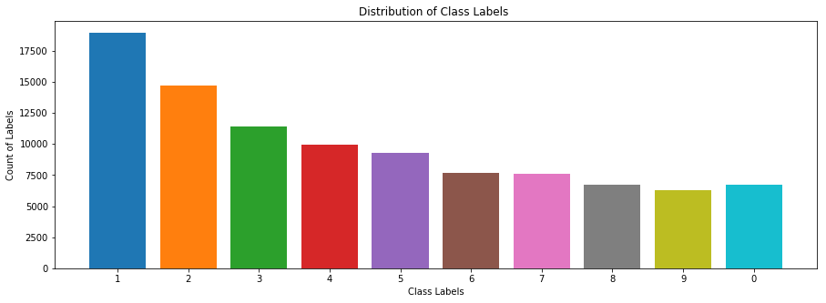

```python
from collections import Counter
c=Counter(list(labelAll.flatten()))
c=dict(c)

fig=plt.figure(figsize=(15,5))
for label in sorted(list(c.keys())):
    plt.bar(x=str(label),height=c[label])
plt.xticks(ticks=np.arange(0,10)  ,labels=("1","2","3","4","5","6","7","8","9","0")  )
plt.title("Distribution of Class Labels ")
plt.xlabel("Class Labels")
plt.ylabel("Count of Labels")
plt.show()
```

## Visualization

#### Original Size Images (32x32x3):

The following shows the images with theirs class labels. As shown, images might contains more than one digits on the same image and our goal is to only classify the center digit on the images. The quality of clarity on images varies, some of them are very manifest ; some of them are blurred. For this reason, the images are being tested by increasing the pixels of images to see whether the quality of clarity is improved.

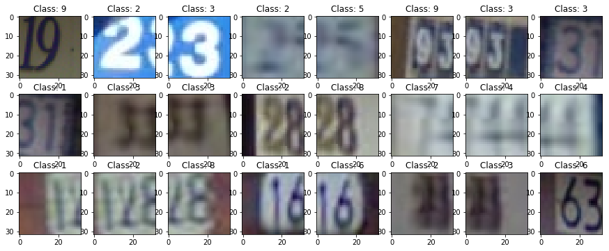

```python
fig=plt.figure(figsize=(15,10))
for i in range(1,25):
    pic=mat["X"][:,:,:,i]
    label=mat["y"][i][0]
    ax=fig.add_subplot(5,8,i)
    #img = Image.fromarray(pic, 'RGB')
    ax.set_title("Class: "+str(label))
    ax.imshow(pic)
plt.show()
```

#### Enriched Image 128x128x3:

As we see below, the quality of clarity of images with higher resolution are being improved. The change is not very apparent to our human eyes, however, some of the digits' edges are more smoothed / shaped than before. This result might offers us hints that the change of colors / pixels of images might help for boosting images classification. So that, we will observe the channels of colors as well as the grayscale individually in the later sections.

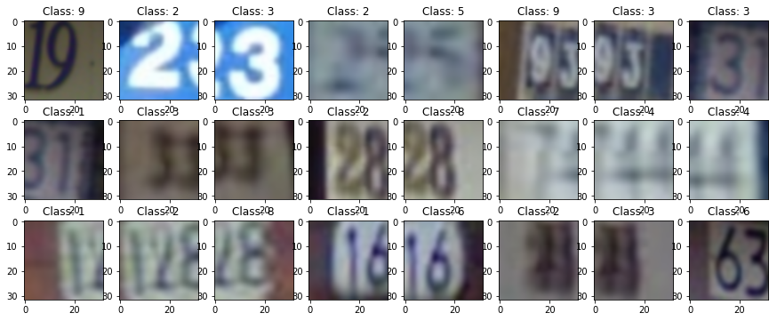

```python
fig=plt.figure(figsize=(15,10))
for i in range(1,25):
    pic=mat["X"][:,:,:,i]
    label=mat["y"][i][0]
    fig.add_subplot(5,8,i)
    pic = Image.fromarray(pic, 'RGB')
    pic.thumbnail((128, 128), Image.ANTIALIAS) # resizes image in-place
    plt.title("Class: "+str(label))
    plt.imshow(pic, interpolation="bicubic")
plt.show()
```

#### Image in three Individual channel (Colors): R / G / B

The following shows the three separated channel of colors of the two images. As we observed, the visualized effect is completely different from the above. The boundary of digits are more stand out from the background on all three individual layers although their intensity (i.e. Darker or lighter) of color are varied. For the goal of this project, we should consider to utilize this monotonous color to make prediction on these images. The next part we will find another type of comon color (i.e. Grayscale) of images for machine learning purpose.

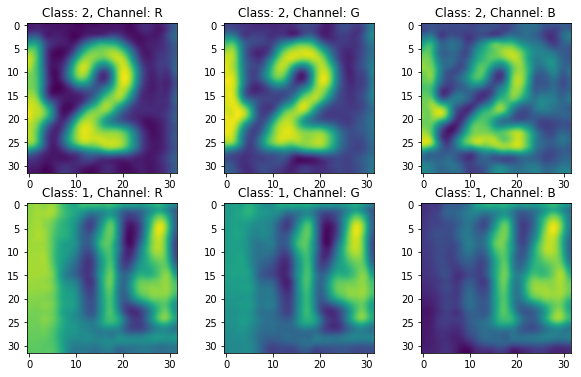

```python
fig=plt.figure(figsize=(10,16))
colors=["R","G","B"]
j=1
for i in [27,1932]:
    for layer in range(0,3):
        pic=mat["X"][:,:,:,i]
        pic=pic[:,:,layer]
        label=mat["y"][i][0]
        fig.add_subplot(5,3,j)
        plt.title("Class: %s, Channel: %s"%(str(label), colors[layer]))
        plt.imshow(pic, interpolation="bicubic")
        j+=1
plt.show()
```

#### Images in GrayScale: (Data for Classification)

There are many different ways to visualize GrayScale images, there are three methods were researched are practiced in this exercise as shown following:

The GrayScale images from all three different methods comes out very similar outcomes. Comparing with the above, the boundary of digits are more stand out from the original channel of colors. In this case, I would propose to use the greyscale set of data to build the classifiers to achieve our project goal.

```python
'''Display images in series'''
def plot_series_image(images, labels,start, end):
    cols=7
    fig=plt.figure(figsize=(10,6))
    for i in range(start,end):
        pic=images[i]
        label=labels[i][0]
        if label == int(10): label=0
        ax=fig.add_subplot(math.ceil((end-start)/cols ),cols,i-start+1)

        #options to plot RBG or 1 channel
        if pic.shape[2]==3:
            ax.imshow(pic)
        else:
            ax.imshow(pic[:,:,0], cmap="binary")
        plt.title("Class: "+str(label))
    plt.show()

#plot_series_image(RBG2GrayFunc(images), mat["y"],1,36)
```

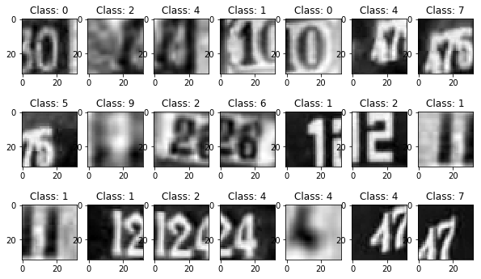

```python
grays=np.expand_dims(np.dot(imageAll, [0.2989, 0.5870, 0.1140]), axis=3).astype(np.float32)
plot_series_image(grays, labelAll,2000, 2021)
```

#### Method 2: Skimage library from Sklearn library

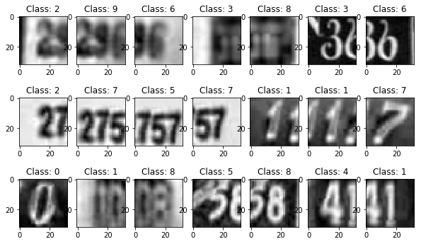

```python
from skimage.color import rgb2gray
#from skimage import data

grays = rgb2gray(imageAll)
grays=grays.reshape(grays.shape[0],grays.shape[1],grays.shape[2],1)
plot_series_image(grays, labelAll,3000, 3021)
```

#### Method 3: Calculate the Mean value of last color channel

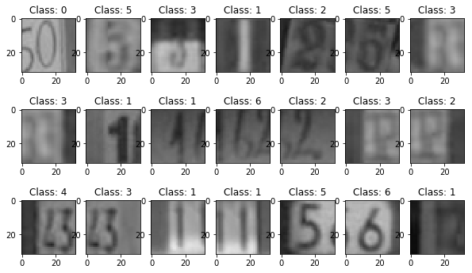

```python
def RBG2GrayFunc(images):
    images[:] = images.mean(axis=-1,keepdims=1)
    return (images)

#images=reshapeImage(mat["X"])
grays=RBG2GrayFunc(imageAll)
plot_series_image(grays, labelAll,5000, 5021)
```

## Colors Distribution for 10 Classes

The following shows the color distribution of each class of images. Unfortunately, it is very hard to find any correlation of colors with Target class labels. In this case, we will do data dimension reduction (i.e. PCA) in the next part to check any particular pattern of data versus the Target labels.

```python
'''Function to plot First 10 Images for each Class'''
def PlotHist(input_array,class_label):
    idx_lst = np.where(input_array.ravel()== int(class_label))[0]

    fig=plt.figure(figsize=(15,2))
    for i in range(1,11):
        fig.add_subplot(1,11,i)
        pic=mat["X"][:,:,:,idx_lst[i]]
        plt.hist(pic.ravel(), bins=256, color="orange",)
        if i >1: plt.yticks([])
    if class_label ==int(10): class_label=0
    fig.suptitle('Class %s Distribution'%(str(class_label)), fontsize=15)
    plt.show()
```

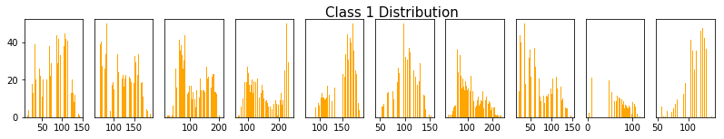

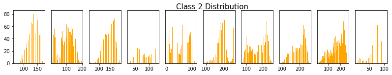

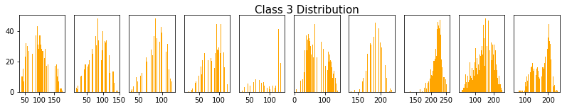

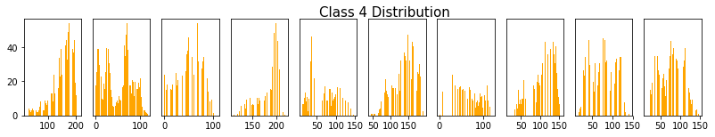

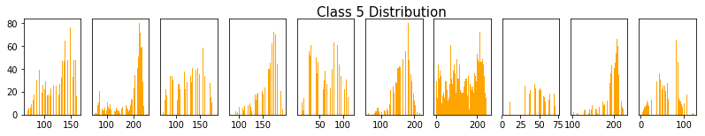

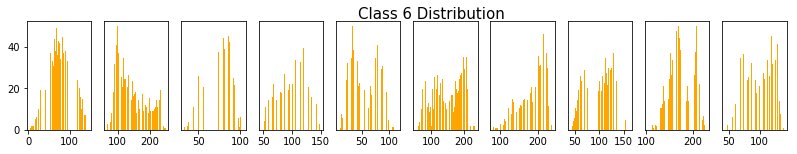

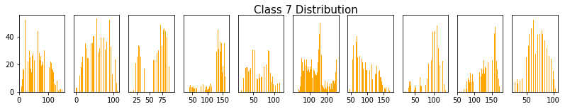

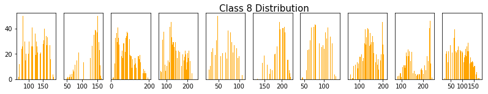

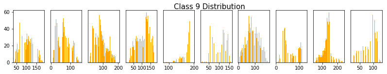

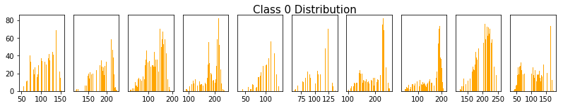

```python
for i in  list(np.unique(mat["y"])):
    PlotHist(mat["y"],i)
```

## Dimension Reduction (PCA)

The following plots show the Principal Component(n=2) of original data and normalized data for 10-class labels. As shown, it is hard to find any correlations between class labels. The data points are mostly piled up along the x-y axis. The major difference of plots are the range of components of original data is a lot wider than the range of components of normalized data. This outcome are as expected because normalized data features are all rescaled into one standard range. For the purpose of modeling, utilizing normalized data not only able to lower computation space also avoiding chance of bias on updating weights backprogation procedure in Deep Learning process (i.e. If we use not normalized data for learning process, the distributon of some features with larger values might over compensating the correction during backprogation; the features with smaller values might just under compensating the corrections). For the above reasons, I would propose to utilize the normalized data for the Deep Learning modeling process.

```python
'''Flatten the image array to 2 dimenision for PCA'''
flatten_image=[]
for i in range(0,imageAll.shape[0]):
    flatten_image.append(imageAll[i].flatten())

flatten_image=np.array(flatten_image)
flatten_image.shape
```

```
(99289, 3072)
```

```python
'''PCA(n=2) for Images Array'''
from sklearn.decomposition import PCA
pca=PCA(n_components=2)
pcaImageAll=pca.fit_transform(flatten_image)
pcaImageAll.shape
```

```
(99289, 2)
```

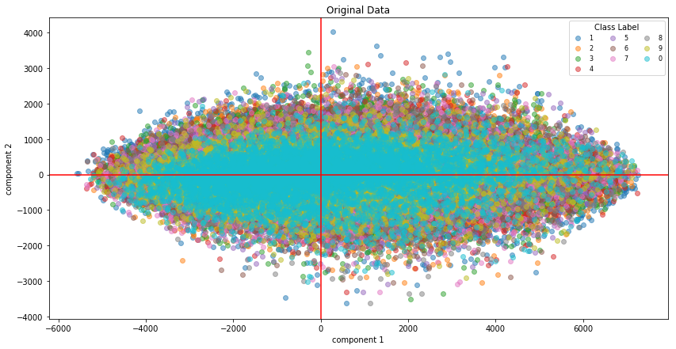

```python
'''Plot the PCA(n=2)'''
fig=plt.figure(figsize=(14,7))

for i in range(1,11):
    idx_lst = np.where(labelAll.flatten()== int(i))[0]
    plt.scatter(pcaImageAll[idx_lst][:,0], pcaImageAll[idx_lst][:,1],cmap="cm", alpha=0.5)
plt.legend(title="Class Label",
           labels=('1', '2', '3', '4', '5', '6', '7','8','9','0'),
           scatterpoints=1,
           loc='upper right',
           ncol=3,
           fontsize=8)

plt.xlabel("component 1")
plt.ylabel("component 2")
plt.title("Original Data")
plt.axvline(x=0, color="red")
plt.axhline(y=0, color="red")
plt.show()
```

```python
'''Normalize the original image array'''
grays = rgb2gray(imageAll) #RBG to Gray
grays=grays.reshape(grays.shape[0],grays.shape[1],grays.shape[2],1)

grays_mean=np.mean(grays, axis=0)
grays_std=np.std(grays, axis=0)

grays_norm=(grays-grays_mean) / grays_std


'''Save the Normalizated data and labels to pickle for modeling purpose'''
import pickle
with open("./data/imagePickle", "wb") as file:
    pickle.dump(grays_norm, file)

with open("./data/labelPickle", "wb") as file:
    pickle.dump(labelAll, file)
```

```python
"""Flatten the image array for PCA purpose"""
flatten_grays_norm=[]
for i in range(0,grays_norm.shape[0]):
    flatten_grays_norm.append(grays_norm[i].flatten())

flatten_grays_norm=np.array(flatten_grays_norm)
flatten_grays_norm.shape
```

```
(99289, 1024)
```

```python
"""PCA(n=2)"""
from sklearn.decomposition import PCA
pca=PCA(n_components=2)
pca_flatten_grays_norm=pca.fit_transform(flatten_grays_norm)
pca_flatten_grays_norm.shape
```

```
(99289, 2)
```

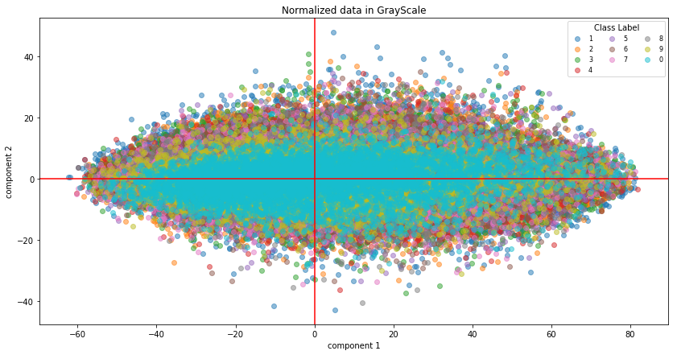

```python
"""Plot PCA(n=2) on GrayScale images"""

fig=plt.figure(figsize=(14,7))

for i in range(1,11):
    idx_lst = np.where(labelAll.flatten()== int(i))[0]
    plt.scatter(pca_flatten_grays_norm[idx_lst][:,0],
                pca_flatten_grays_norm[idx_lst][:,1],cmap="cm", alpha=0.5)
plt.legend(title="Class Label",
           labels=('1', '2', '3', '4', '5', '6', '7','8','9','0'),
           scatterpoints=1,
           loc='upper right',
           ncol=3,
           fontsize=8)

plt.xlabel("component 1")
plt.ylabel("component 2")
plt.title("Normalized data in GrayScale")
plt.axvline(x=0, color="red")
plt.axhline(y=0, color="red")
plt.show()
```

## Modeling

This part shows the modeling of image classification, we first splitted the original dataset into Train and Test set (i.e. 67% vs 33%). As shown below, the class labels are proportionally splitted which is shown on the charts below. In addition, the one-dimensional label array will be converted to binary matrix by "to_categorical" function for model training purpose. The models are tested by Convolutional Keras library with various activation functions, there are Eight tested models in total.

```python
from sklearn.model_selection import train_test_split
import pickle
#Reopen the X and y file
with open("./data/imagePickle", "rb") as file:
    X=pickle.load(file)
with open("./data/labelPickle", "rb") as file:
    y=pickle.load(file)

print(X.shape, y.shape)

'''Splitting dataset into Train and Test Set'''
X_train, X_test, y_train, y_test = train_test_split(X, y, test_size=0.33, random_state=42)

print("X train shape:",X_train.shape)
print("y train shape:",y_train.shape)
print()
print("X test shape:", X_test.shape)
print("y test shape:", y_test.shape)
```

```
(99289, 32, 32, 1) (99289, 1)
X train shape: (66523, 32, 32, 1)
y train shape: (66523, 1)

X test shape: (32766, 32, 32, 1)
y test shape: (32766, 1)
```

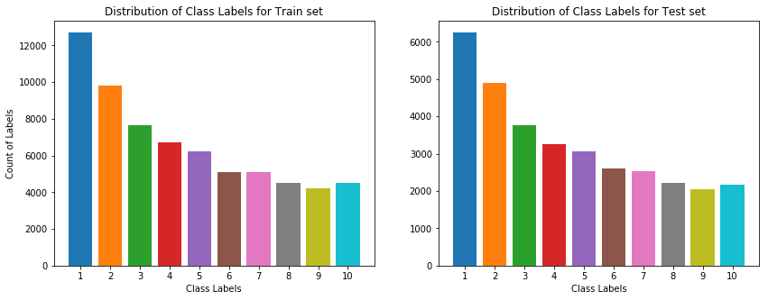

```python
'''Plotting the distribution of Train and Test set data'''
from collections import Counter
c=Counter(list(y_train.flatten()))
c=dict(c)
fig=plt.figure(figsize=(14,5))

for label in sorted(list(c.keys())):
    ax=fig.add_subplot(1,2,1)
    ax.bar(x=str(label),height=c[label])

plt.title("Distribution of Class Labels for Train set")
plt.xlabel("Class Labels")
plt.ylabel("Count of Labels")

c=Counter(list(y_test.flatten()))
c=dict(c)
for label in sorted(list(c.keys())):
    ax=fig.add_subplot(1,2,2)
    ax.bar(x=str(label),height=c[label])
plt.title("Distribution of Class Labels for Test set")
plt.xlabel("Class Labels")

plt.show()
```

```python
# MODEL
from keras.models import Sequential
from keras.layers import Conv2D, MaxPooling2D
from keras.layers import Activation, Dropout, Flatten, Dense
from keras.callbacks import ModelCheckpoint
from keras.utils import to_categorical
import keras
```

```python
'''Conv2d model layers'''
model_no=8
batch_size=200
epoch=400
input_shape = grays_norm.shape[1:]

model = Sequential()
model.add(Conv2D(64, (3, 3), input_shape=input_shape ))
model.add(Activation('relu'))
model.add(MaxPooling2D(pool_size=(2, 2)))

model.add(Dropout(0.25))

model.add(Conv2D(64, (3, 3)))
model.add(Activation('relu'))
model.add(MaxPooling2D(pool_size=(2, 2)))

model.add(Dropout(0.25))

model.add(Conv2D(128, (3, 3)))
model.add(Activation('relu'))
model.add(MaxPooling2D(pool_size=(3, 3)))

model.add(Dropout(0.25))

model.add(Flatten())

# Step 4 - Full connection
model.add(Dense(units = 64, activation = 'relu'))
model.add(Dense(units = 32, activation = 'relu'))
model.add(Dense(units = 11, activation = 'softmax'))

model.summary()
```

```
_________________________________________________________________
Layer (type)                 Output Shape              Param #
=================================================================
conv2d_1 (Conv2D)            (None, 30, 30, 64)        640
_________________________________________________________________
activation_1 (Activation)    (None, 30, 30, 64)        0
_________________________________________________________________
max_pooling2d_1 (MaxPooling2 (None, 15, 15, 64)        0
_________________________________________________________________
dropout_1 (Dropout)          (None, 15, 15, 64)        0
_________________________________________________________________
conv2d_2 (Conv2D)            (None, 13, 13, 64)        36928
_________________________________________________________________
activation_2 (Activation)    (None, 13, 13, 64)        0
_________________________________________________________________
max_pooling2d_2 (MaxPooling2 (None, 6, 6, 64)          0
_________________________________________________________________
dropout_2 (Dropout)          (None, 6, 6, 64)          0
_________________________________________________________________
conv2d_3 (Conv2D)            (None, 4, 4, 128)         73856
_________________________________________________________________
activation_3 (Activation)    (None, 4, 4, 128)         0
_________________________________________________________________
max_pooling2d_3 (MaxPooling2 (None, 1, 1, 128)         0
_________________________________________________________________
dropout_3 (Dropout)          (None, 1, 1, 128)         0
_________________________________________________________________
flatten_1 (Flatten)          (None, 128)               0
_________________________________________________________________
dense_1 (Dense)              (None, 64)                8256
_________________________________________________________________
dense_2 (Dense)              (None, 32)                2080
_________________________________________________________________
dense_3 (Dense)              (None, 11)                363
=================================================================
Total params: 122,123
Trainable params: 122,123
Non-trainable params: 0
_________________________________________________________________
```

```python
'''Model Learning'''

model.compile(loss='categorical_crossentropy',
              optimizer='adam',
              metrics=['accuracy'])


#To save the best model by monitor the "Validation Loss"
checkpoint = ModelCheckpoint(filepath="result/m%s.h5"%(str(model_no)),
                             monitor='val_acc', #Model saved based on Improved Accuracy
                             verbose=1,
                             save_best_only=True,
                             mode='max')

callbacks_lst = [checkpoint]

history=model.fit(X_train, to_categorical(y_train),
          batch_size=batch_size,
          epochs=epoch,
          verbose=1,
          validation_data=(X_test, to_categorical(y_test)),
          callbacks=callbacks_lst)

#Save Model History (Loss vs Epoch)
epochs= np.linspace(1,epoch,epoch,dtype=int)
pd.DataFrame(list(zip(epochs,history.history["loss"],history.history["val_loss"],history.history["acc"],history.history["val_acc"])), \
             columns=["epoch", "loss","val_loss", "acc", "val_acc"]).to_csv("result/history_m%s"%(str(model_no)) )
```

#### Models Accuracy and Loss Comparison

```python
'''Display Models Performance Summary'''

pd.set_option('display.max_colwidth', -1)

df=pd.read_csv("./result/saved_history_model.csv", index_col="model_no").dropna()
display(df.iloc[0:8][["layers", "loss_func",'optimizer',"batch_size","epoch", "val_acc"]])
```

[output not shown]

```python
'''Function to plot Loss/Accuracy on Boxplot and Curve Plot'''
def HistLossAccFunc(history, title):
    plt.figure(figsize=(15,15))
    plt.suptitle(title, fontsize=15)

    # Plots Format
    gs = gridspec.GridSpec(1, 2, width_ratios=[2, 5])

    #Boxplot
    ax1=plt.subplot(gs[0])
    ax1.boxplot(x=[history.acc, history.val_acc, history.loss, history.val_loss], widths=(0.3,0.3,0.3,0.3),
                labels=["train_acc","val_acc","train_loss","val_loss"], patch_artist = True)
    plt.ylabel("Accuracy / Loss", fontsize=18)
    plt.xticks(fontsize=14, rotation=45)
    plt.yticks(fontsize=14)

    # Curve plot
    ax2=plt.subplot(gs[1])
    history.plot(x="epoch", y=["acc", "val_acc","loss", "val_loss"], figsize=(20,5), ax=ax2, style=["--","--","+","+"])
    plt.xlabel("Epoch", fontsize = 18)
    plt.xticks(fontsize=14)
    plt.yticks(fontsize=14)
    plt.legend(fontsize=12)


    plt.text(20,1.1,"Val Accuracy: %0.2f"%(round(max(history.val_acc),3)), fontsize=20, color="blue")

    plt.show()
```

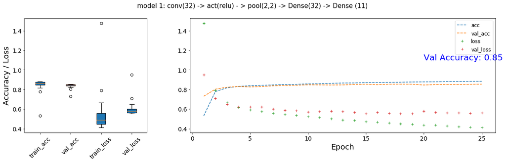

```python
dir="./result/saved_model_history/"
hist=pd.read_csv(dir+"history_m1")
title="model 1: conv(32) -> act(relu) - > pool(2,2) -> Dense(32) -> Dense (11)"
HistLossAccFunc(hist, title)
```

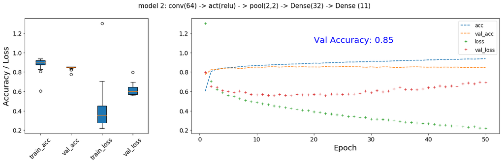

```python
dir="./result/saved_model_history/"
hist=pd.read_csv(dir+"history_m2")
title="model 2: conv(64) -> act(relu) - > pool(2,2) -> Dense(32) -> Dense (11)"
HistLossAccFunc(hist, title)
```

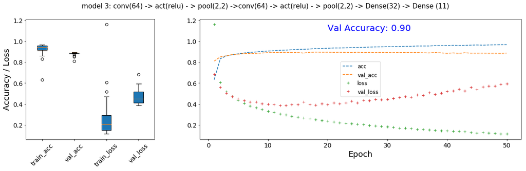

```python
dir="./result/saved_model_history/"
hist=pd.read_csv(dir+"history_m3")
title="model 3: conv(64) -> act(relu) - > pool(2,2) ->conv(64) -> act(relu) - > pool(2,2) -> Dense(32) -> Dense (11)"
HistLossAccFunc(hist, title)
```

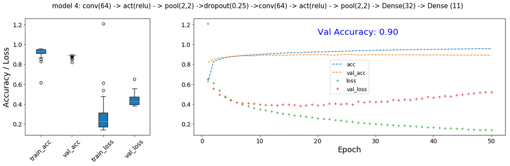

```python
dir="./result/saved_model_history/"
hist=pd.read_csv(dir+"history_m4")
title="model 4: conv(64) -> act(relu) - > pool(2,2) ->dropout(0.25) ->conv(64) -> act(relu) - > pool(2,2) -> Dense(32) -> Dense (11)"
HistLossAccFunc(hist, title)
```

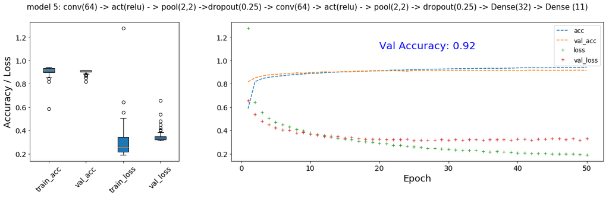

```python
dir="./result/saved_model_history/"
hist=pd.read_csv(dir+"history_m5")
title="model 5: conv(64) -> act(relu) - > pool(2,2) ->dropout(0.25) -> conv(64) -> act(relu) - > pool(2,2) -> dropout(0.25) -> Dense(32) -> Dense (11)"
HistLossAccFunc(hist,title)
```

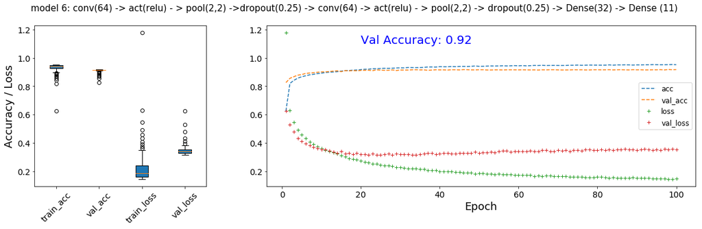

```python
dir="./result/saved_model_history/"
hist=pd.read_csv(dir+"history_m6")
title="model 6: conv(64) -> act(relu) - > pool(2,2) ->dropout(0.25) -> conv(64) -> act(relu) - > pool(2,2) -> dropout(0.25) -> Dense(32) -> Dense (11)"
HistLossAccFunc(hist,title)
```

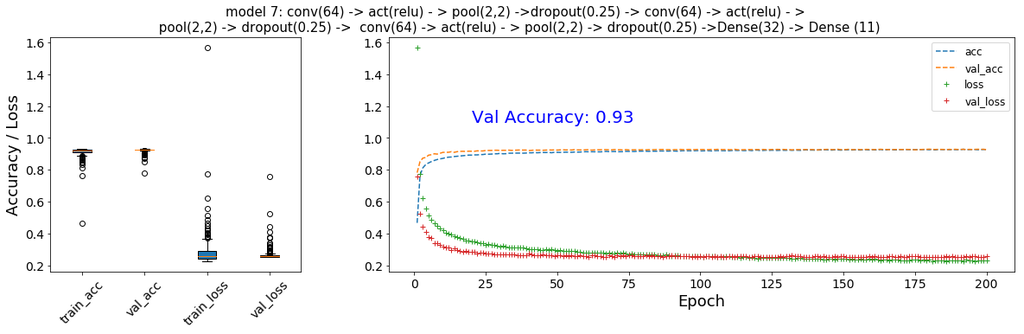

```python
dir="./result/saved_model_history/"
hist=pd.read_csv(dir+"history_m7")
title="model 7: conv(64) -> act(relu) - > pool(2,2) ->dropout(0.25) -> conv(64) -> act(relu) - > \n pool(2,2) -> dropout(0.25) ->  conv(64) -> act(relu) - > pool(2,2) -> dropout(0.25) ->Dense(32) -> Dense (11)"
HistLossAccFunc(hist,title)
```

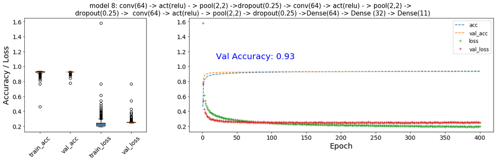

```python
dir="./result/saved_model_history/"
hist=pd.read_csv(dir+"history_m8")
title="model 8: conv(64) -> act(relu) - > pool(2,2) ->dropout(0.25) -> conv(64) -> act(relu) - > pool(2,2) -> \n dropout(0.25) ->  conv(64) -> act(relu) - > pool(2,2) -> dropout(0.25) ->Dense(64) -> Dense (32) -> Dense(11)"

HistLossAccFunc(hist,title)
```